# RNA-Seq Tutorial

Kent Riemondy  
03/14/2017

### Outline

- Introduce RNA-Seq Methods and Analysis
- RNA-Seq Vignette
- EDA analysis

### What is RNA-Seq?

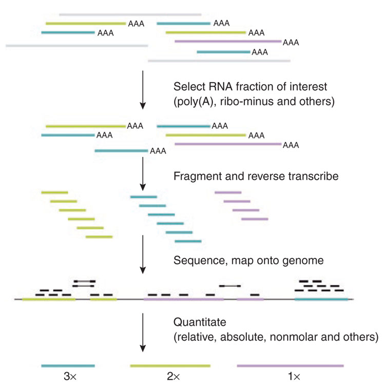

Computation for ChIP-seq and RNA-seq studies. Nature Methods 2009.

### Types of RNA-Seq methods

- Poly-A+/-Seq
- 3'end-Seq
- Clip-Seq
- Ribo-Seq
- RNA modification-seqs
- Single-Cell RNA-Seq

### Tools for mRNA-Seq Analysis

- Align reads to genome
  - Bowtie2
  - **Tophat2/Hisat2**
  - STAR
  - Kallisto/Salmon
- Count reads per gene
  - **featureCounts (Rsubread R pkg)**
  - HTSeq-count (Python script)
  - Bedtools multicov (Command line C++)
  - RSEM/Kallisto/Salmon (Command line C++)
- Differential Expression
  - **DESeq2**
  - edgeR
  - Sleuth (works with Kallisto/RSEM)
  - Alpine
- Exploratory Data Analysis
  - Heatmaps (Complex Heatmap (R pkg))
  - GO analysis (TopGO, DAVID)
  - GSEA (Broad Insitute)
  - Clustering (`prcomp()`, `kmeans()`)

### How to count reads per gene?

- Assign alignment to a genome feature (gene/transcript/exon)
- How to handle reads that align to multiple places?
- How much overlap necessary?
- How to handle overlapping annotations?
- One approach
  - Count only high quality alignments (*uniquely aligned*)
  - Discard alignments overlapping multiple annotations

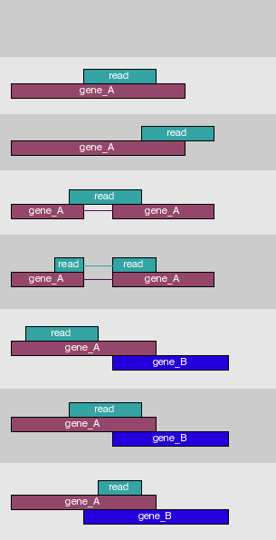

Modified from HTSeq [documentation](http://www-huber.embl.de/users/anders/HTSeq/doc/index.html).

### Count Matrix

```r
head(countData)
```

```
            treated1 treated2 treated3 untreated1 untreated2 untreated3
FBgn0000003        0        0        1          0          0          0
FBgn0000008      140       88       70         92        161         76
FBgn0000014        4        0        0          5          1          0
FBgn0000015        1        0        0          0          2          1
FBgn0000017     6205     3072     3334       4664       8714       3564
FBgn0000018      722      299      308        583        761        245
            untreated4
FBgn0000003          0
FBgn0000008         70
FBgn0000014          0
FBgn0000015          2
FBgn0000017       3150
FBgn0000018        310
```

To generate a count matrix you need:

- Alignment files ([BAM](https://samtools.github.io/hts-specs/SAMv1.pdf))
- Annotation file (Gene Transfer Format [GTF](http://uswest.ensembl.org/info/data/ftp/index.html), [description](http://plants.ensembl.org/info/website/upload/gff.html))
- featureCounts, HTSeq-Count, Bedtools

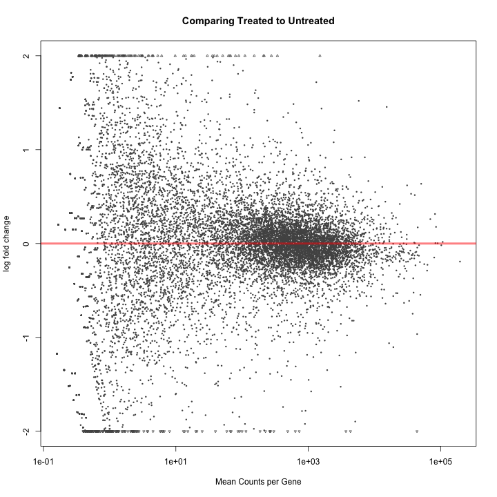

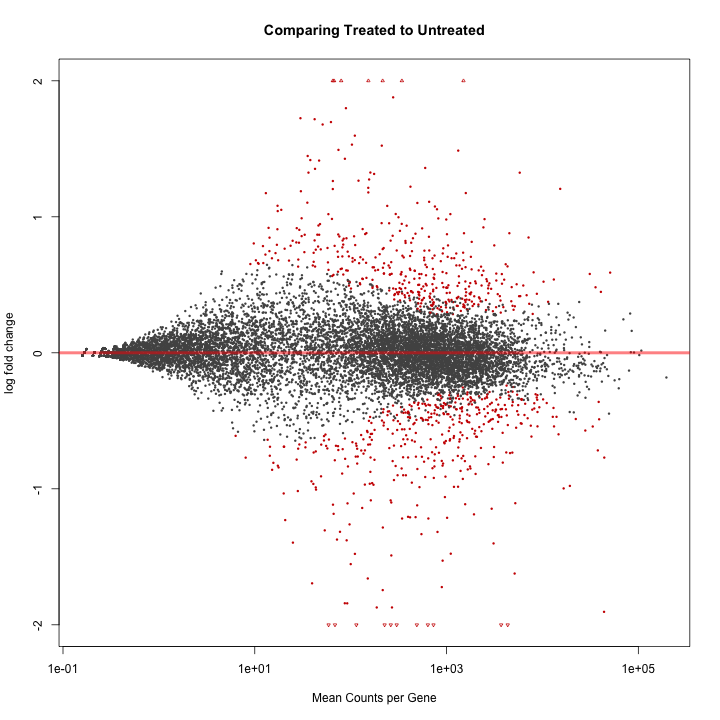

### Basic Steps for DESeq2 analysis

- Normalize between different samples (reduce effects from different sequencing depths)
- estimate dispersion for each gene to fit a model
- fit to a negative binomial glm.
- perform statistical tests based on supplied model design

```r
# single factor
design = ~ treatment

#multiple factor
design = ~ treatment + disease
```

DESeq2 [paper](http://genomebiology.biomedcentral.com/articles/10.1186/s13059-014-0550-8)